# Factors - r4ds

2019-05-15

## ファクタ

カテゴリ変数を扱う技術

### 準備

```r
library(tidyverse)
library(forcats)
```

神世界の一部だが、一括でロードはされない

関数はすべて`fct_`で始まる

## 尺度水準

そもそもカテゴリ変数とは？

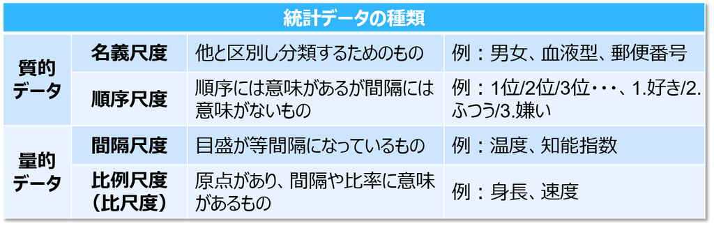

[wikipedia](https://en.wikipedia.org/wiki/Level_of_measurement)

## 15.2 Creating Factor

ファクタを作る

## factor

```r
x1 <- c("Dec", "Apr", "Jan", "Mar")
y1 <- factor(x1, levels = c("Jan", "Feb", "Mar", "Apr", "May", "Jun", "Jul", "Aug", "Sep", "Oct", "Nov", "Dec"))
y1
```

```
## [1] Dec Apr Jan Mar
## Levels: Jan Feb Mar Apr May Jun Jul Aug Sep Oct Nov Dec
```

`levels`に存在しない要素は`NA`

```r
x2 <- c("Dec", "Apr", "Jam", "Mar")
y2 <- factor(x2, levels = c("Jan", "Feb", "Mar", "Apr", "May", "Jun", "Jul", "Aug", "Sep", "Oct", "Nov", "Dec"))
y2
```

```
## [1] Dec  Apr  <NA> Mar
## Levels: Jan Feb Mar Apr May Jun Jul Aug Sep Oct Nov Dec
```

## 順序のコントロール

順序指定なしだとアルファベット順

```r
factor(x1)
```

```
## [1] Dec Apr Jan Mar
## Levels: Apr Dec Jan Mar
```

最初に現れた順

```r
factor(x1, levels = unique(x1))
```

```
## [1] Dec Apr Jan Mar
## Levels: Dec Apr Jan Mar
```

## levels

factorの`levels`を文字列ベクトルとして取得

```r
y1 <- factor(x1, levels = c("Jan", "Feb", "Mar", "Apr", "May", "Jun", "Jul", "Aug", "Sep", "Oct", "Nov", "Dec"))
levels(y1)
```

```
##  [1] "Jan" "Feb" "Mar" "Apr" "May" "Jun" "Jul" "Aug" "Sep" "Oct" "Nov"
## [12] "Dec"
```

## 15.3 General Social Survey

今回扱うデータについて

## `gss_cat`

```r
forcats::gss_cat
```

```
## # A tibble: 21,483 x 9
##     year marital     age race  rincome   partyid   relig   denom   tvhours
##    <int> <fct>     <int> <fct> <fct>     <fct>     <fct>   <fct>     <int>
##  1  2000 Never ma…    26 White $8000 to… Ind,near… Protes… Southe…      12
##  2  2000 Divorced     48 White $8000 to… Not str … Protes… Baptis…      NA
##  3  2000 Widowed      67 White Not appl… Independ… Protes… No den…       2
##  4  2000 Never ma…    39 White Not appl… Ind,near… Orthod… Not ap…       4
##  5  2000 Divorced     25 White Not appl… Not str … None    Not ap…       1
##  6  2000 Married      25 White $20000 -… Strong d… Protes… Southe…      NA
##  7  2000 Never ma…    36 White $25000 o… Not str … Christ… Not ap…       3
##  8  2000 Divorced     44 White $7000 to… Ind,near… Protes… Luther…      NA
##  9  2000 Married      44 White $25000 o… Not str … Protes… Other         0
## 10  2000 Married      47 White $25000 o… Strong r… Protes… Southe…       3
## # ... with 21,473 more rows
```

## 探索1

```r
gss_cat %>% count(race)
```

```
## # A tibble: 3 x 2
##   race      n
##   <fct> <int>
## 1 Other  1959
## 2 Black  3129
## 3 White 16395
```

## 探索2

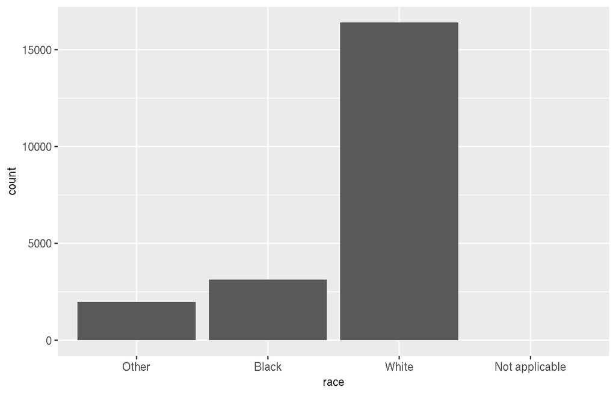

```r
gss_cat %>%
  ggplot(aes(race)) + geom_bar() + scale_x_discrete(drop = FALSE)
```

## 練習問題

1~3

## 15.4 Modifying factor order

ファクタの順序の変更

特にグラフを作るときは順序を変更したいよね

## 準備

宗教ごとの平均テレビ視聴時間

```r
relig_summary <- gss_cat %>%
  group_by(relig) %>%
  summarise(
    age = mean(age, na.rm = TRUE),
    tvhours = mean(tvhours, na.rm = TRUE),
    n = n()
  )
relig_summary
```

```
## # A tibble: 15 x 4
##    relig                     age tvhours     n
##    <fct>                   <dbl>   <dbl> <int>
##  1 No answer                49.5    2.72    93
##  2 Don't know               35.9    4.62    15
##  3 Inter-nondenominational  40.0    2.87   109
##  4 Native american          38.9    3.46    23
##  5 Christian                40.1    2.79   689
##  6 Orthodox-christian       50.4    2.42    95
##  7 Moslem/islam             37.6    2.44   104
##  8 Other eastern            45.9    1.67    32
##  9 Hinduism                 37.7    1.89    71
## 10 Buddhism                 44.7    2.38   147
## 11 Other                    41.0    2.73   224
## 12 None                     41.2    2.71  3523
## 13 Jewish                   52.4    2.52   388
## 14 Catholic                 46.9    2.96  5124
## 15 Protestant               49.9    3.15 10846
```

## 可視化

なんだか分かりにくい

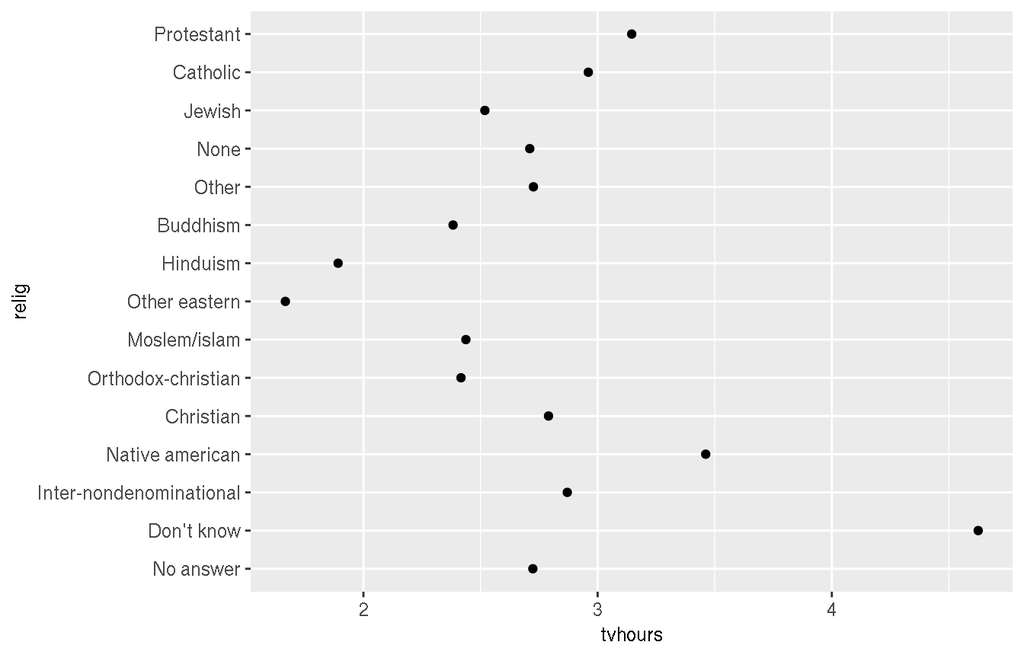

```r
ggplot(relig_summary, aes(tvhours, relig)) + geom_point()
```

## `fct_reorder`

### Usage

```r
fct_reorder(.f, .x, .fun = median, ..., .desc = FALSE)
```

### Arguments

| **.f** | factor変数(char変数でも可) |
| --- | --- |
| **.x** | funを使って順序を決定するために使う変数 |
| **.fun** | 集計関数(ベクトルを受けて値を返す)。デフォルトは`median` |
| **…** | 集計関数に渡すパラメータ。たとえば`na.rm = TRUE` |
| **.desc** | 順番を逆にする |

## わかりやすくなった

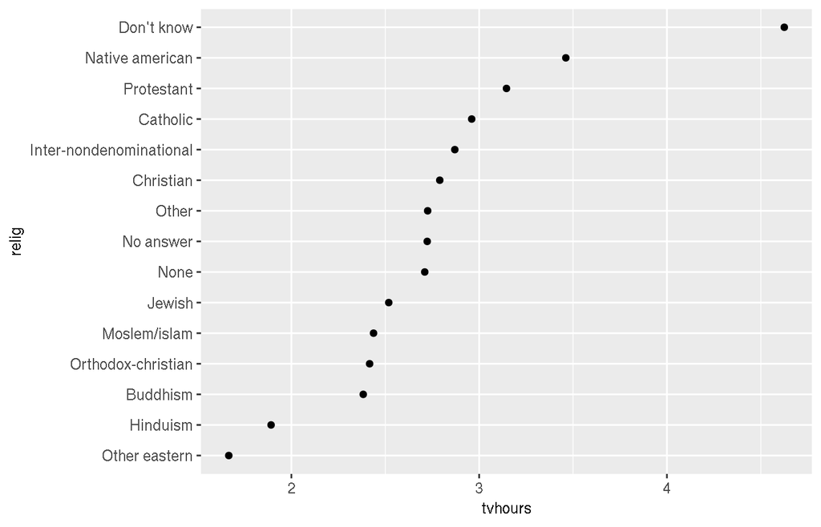

```r
relig_summary %>%
  mutate(relig = fct_reorder(relig, tvhours)) %>%
  ggplot(aes(tvhours, relig)) + geom_point()
```

## もう一例

年齢と収入との関係

```r
rincome_summary <- gss_cat %>%
  group_by(rincome) %>%
  summarise(
    age = mean(age, na.rm = TRUE),
    tvhours = mean(tvhours, na.rm = TRUE),
    n = n()
  )
rincome_summary
```

```
## # A tibble: 16 x 4
##    rincome          age tvhours     n
##    <fct>          <dbl>   <dbl> <int>
##  1 No answer       45.5    2.90   183
##  2 Don't know      45.6    3.41   267
##  3 Refused         47.6    2.48   975
##  4 $25000 or more  44.2    2.23  7363
##  5 $20000 - 24999  41.5    2.78  1283
##  6 $15000 - 19999  40.0    2.91  1048
##  7 $10000 - 14999  41.1    3.02  1168
##  8 $8000 to 9999   41.1    3.15   340
##  9 $7000 to 7999   38.2    2.65   188
## 10 $6000 to 6999   40.3    3.17   215
## 11 $5000 to 5999   37.8    3.16   227
## 12 $4000 to 4999   38.9    3.15   226
## 13 $3000 to 3999   37.8    3.31   276
## 14 $1000 to 2999   34.5    3.00   395
## 15 Lt $1000        40.5    3.36   286
## 16 Not applicable  56.1    3.79  7043
```

## 可視化

縦軸の順序に意味があるから`reorder`してはいけない

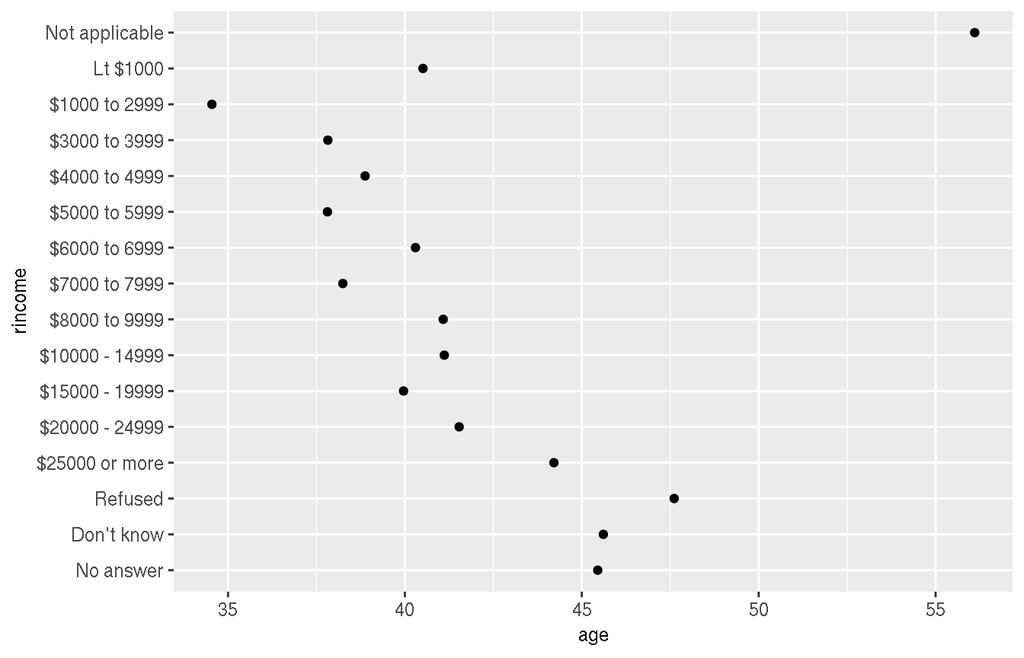

```r
ggplot(rincome_summary, aes(age, rincome)) + geom_point()
```

## `fct_relevel`

### Usage

```r
fct_relevel(.f, ..., after = 0L)
```

### Auguments

[output not shown]

## 一個だけ動かした

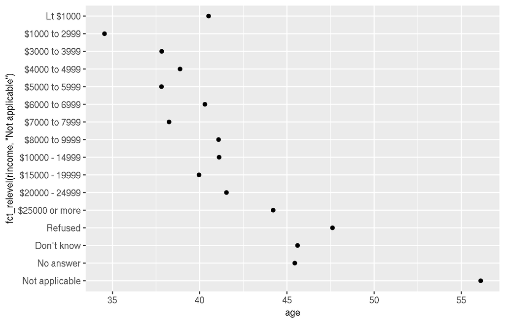

```r
ggplot(rincome_summary, aes(age, fct_relevel(rincome, "Not applicable"))) +
  geom_point()
```

## 色と線との対応が分かりにくい

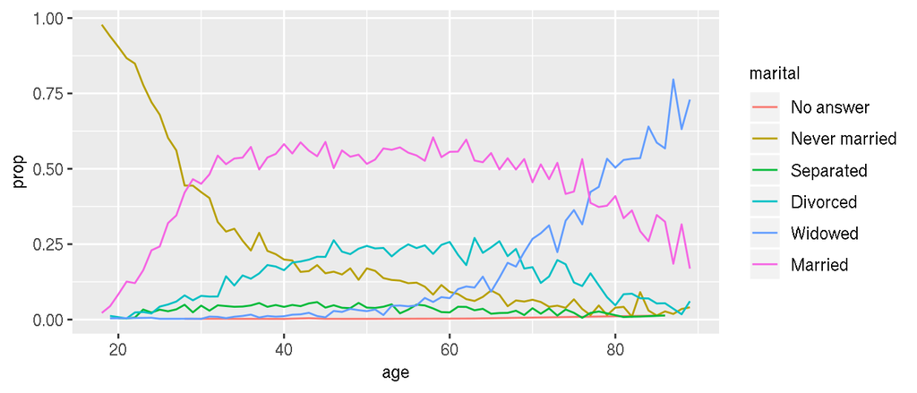

```r
by_age <- gss_cat %>%
  filter(!is.na(age)) %>%
  count(age, marital) %>%
  group_by(age) %>%
  mutate(prop = n / sum(n))
ggplot(by_age, aes(age, prop, colour = marital)) +
  geom_line(na.rm = TRUE)
```

## `fct_reorder2`

ファクタ.fを.xが一番大きいときの.yの順序で並び替える

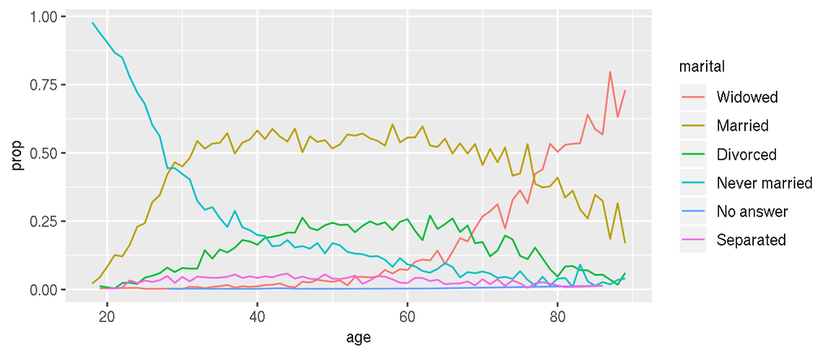

```r
ggplot(by_age, aes(age, prop, colour = fct_reorder2(marital, age, prop))) +
  geom_line() +
  labs(colour = "marital")
```

## `fct_infreq`

頻度でソート

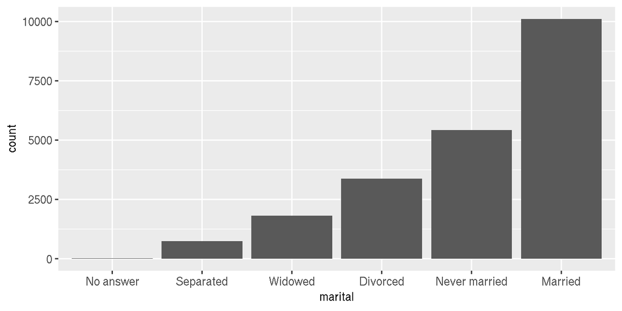

```r
gss_cat %>%
  mutate(marital = marital %>% fct_infreq() %>% fct_rev()) %>%
  ggplot(aes(marital)) + geom_bar()
```

## 練習問題

1~3

## 15.5 Modifying factor levels

ファクタの中身を修正する。

実践で使う

## 支持する政党

```r
gss_cat %>% count(partyid)
```

```
## # A tibble: 10 x 2
##    partyid                n
##    <fct>              <int>
##  1 No answer            154
##  2 Don't know             1
##  3 Other party          393
##  4 Strong republican   2314
##  5 Not str republican  3032
##  6 Ind,near rep        1791
##  7 Independent         4119
##  8 Ind,near dem        2499
##  9 Not str democrat    3690
## 10 Strong democrat     3490
```

表現が一貫していなくてクソ

## 修正

```r
gss_cat %>%
  mutate(partyid = fct_recode(partyid,
    "Republican, strong"    = "Strong republican",
    "Republican, weak"      = "Not str republican",
    "Independent, near rep" = "Ind,near rep",
    "Independent, near dem" = "Ind,near dem",
    "Democrat, weak"        = "Not str democrat",
    "Democrat, strong"      = "Strong democrat",
    "Other"                 = "No answer",
    "Other"                 = "Don't know",
    "Other"                 = "Other party"
  )) %>%
  count(partyid)
```

[output not shown]

## まとめて修正

```r
gss_cat %>%
  mutate(partyid = fct_collapse(partyid,
    other = c("No answer", "Don't know", "Other party"),
    rep = c("Strong republican", "Not str republican"),
    ind = c("Ind,near rep", "Independent", "Ind,near dem"),
    dem = c("Not str democrat", "Strong democrat")
  )) %>%
  count(partyid)
```

```
## # A tibble: 4 x 2
##   partyid     n
##   <fct>   <int>
## 1 other     548
## 2 rep      5346
## 3 ind      8409
## 4 dem      7180
```

## 集約

```r
gss_cat %>%
  mutate(relig = fct_lump(relig, n = 2)) %>%
  count(relig)
```

```
## # A tibble: 3 x 2
##   relig          n
##   <fct>      <int>
## 1 Catholic    5124
## 2 Protestant 10846
## 3 Other       5513
```

グラフ描く時とか便利

## 練習問題

1~2

## 参考情報

- [尺度水準(wikipedia)](https://en.wikipedia.org/wiki/Level_of_measurement)
- [変数の尺度(統計ことはじめ)](https://bellcurve.jp/statistics/course/1562.html)